# R Notebook

K-means is an unsupervised machine learning clustering algorithm. It can be used to cluster a set of observations based on similarity between the observations. K-means is one of the most popular clustering technique and it is quite simple to understand.

The goal of this algorithm is to the find the optimal division of `n` observations into `k` clusters, so that the total squared distance of the group members to the cluster centroid is minimized.

$W(C_k) = \Sigma_{x_i\in C_k}(x_i-\mu_k)^2$

- $x_i$ is an observation assigned to cluster $C_k$
- $\mu_k$ is the mean value of all observations assigned to cluster $C_k$ (i.e, the centroid)

The K-means algorithm attempts to do the follow:

1. Initialize `k` number of clusters.
2. `k` number of observations are randomly selected to be the initial centroids.
3. Determine the distance between observations and the centroids. This can be done by a variety of distance metrics. A commmon one is the Euclidean distance.
4. Assign each observation to the nearest centroid.
5. Recalculate new centroid position. This is done by updating the centroid coordinates by taking the average of all values of each observations that are part of the cluster.
6. Steps 3 - 5 are repeated iteratively until a maximum number of iterations are reached or the observations no longer assigned to another cluster.

We can develop a simple K-means function using the above algorithm. Here we have a data set `USArrests`, which contains statistics for arrests per 100,000 residents in each state for either murder, assult, or rape. In addition, the percentage o people living in urban areas is also listed.

|  | Murder | Assault | UrbanPop | Rape |
| --- | --- | --- | --- | --- |
| Alabama | 13.2 | 236 | 58 | 21.2 |
| Alaska | 10.0 | 263 | 48 | 44.5 |
| Arizona | 8.1 | 294 | 80 | 31.0 |
| Arkansas | 8.8 | 190 | 50 | 19.5 |
| California | 9.0 | 276 | 91 | 40.6 |
| Colorado | 7.9 | 204 | 78 | 38.7 |

The data is then scaled to standardize the values.

```r
USArrests_scaled <- scale(USArrests)
head(USArrests_scaled)
```

```
               Murder   Assault   UrbanPop         Rape
Alabama    1.24256408 0.7828393 -0.5209066 -0.003416473
Alaska     0.50786248 1.1068225 -1.2117642  2.484202941
Arizona    0.07163341 1.4788032  0.9989801  1.042878388
Arkansas   0.23234938 0.2308680 -1.0735927 -0.184916602
California 0.27826823 1.2628144  1.7589234  2.067820292
Colorado   0.02571456 0.3988593  0.8608085  1.864967207
```

We can use principal component analysis to generate a low-dimensional representation of the graph.

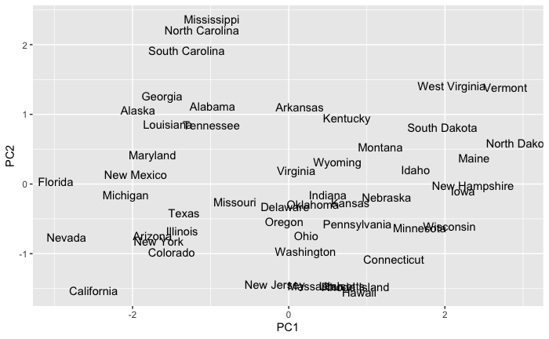

We can already see possible clusters or grouping of states with similar statistics. Let’s start with an easy `k` value of `2`. We initialize `k` and select for centroids.

```r
k = 2
centroids = sample.int(dim(USArrests_scaled)[1], k) #randomly select k integers from 1 to the length of the data.
centroid_points = USArrests_scaled[centroids,] %>% as.matrix() #use the selected integers as indices and select for them in the data frame.
centroid_points
```

```
             Murder   Assault   UrbanPop      Rape
Louisiana 1.7476714 0.9388312 0.03177945 0.1033483
Michigan  0.9900104 1.0108275 0.58446551 1.4806140
```

Next, we use a diistance metric to compare the observation and the centroids. This will result in a matrix that gauges dissimilarity. Observations that are further apart from the centroid and less likely to be part of that cluster. Choice of distance metriic will affect the fformation of the clutsers. Here we choose the Euclidean distance: $d_{euc}(x,y) = \sqrt{\Sigma_{i=1}^{n}(x_i-y_i)^2}$

```r
dataPoints <- as.matrix( USArrests_scaled)
dist_mat <- matrix(0, nrow = nrow(dataPoints), ncol = k) #initialize an empty matrix
for (j in 1:k)
  {
    for (i in 1:nrow(dataPoints))
    {
    dist_mat[i,j] = sqrt(sum((dataPoints[i,1:ncol(dataPoints)] - centroid_points[j,1:ncol(centroid_points)])^2))
    }
  }
head(dist_mat)
```

[output not shown]

The cluster for each observation is chosen by the centroid with the smallest distance to the observation. We can use the `which.min()` function.

```r
cluster = factor(apply(dist_mat, 1, which.min)) #selects the column index with the smallest distance
head(cluster)
```

```
[1] 2 2 2 1 2 2
Levels: 1 2
```

Recall that we are minimizing the squared Euclidean distances between the observation and the assigned centroid. This is also the within-cluster sum of squares (WCSS). $W(C_k) = \Sigma_{x_i\in C_k}(x_i-\mu_k)^2$

We define a total within-cluster sum of squares (total_WCSS) which measures the compactness of the clustering. Minimizing this value results in tighter clusters.

$total_WCSS = \Sigma^k_{k=1}W(C_k) =\Sigma^k_{k=1}\Sigma_{x_i\in C_k}(x_i-\mu_k)^2$

```r
within_cluster_ss <- colSums(dist_mat^2)
cat('Within-cluster sum of squares:', within_cluster_ss, '\n')
```

```
Within-cluster sum of squares: 267.0418 311.076
```

```r
total_WCSS = sum(within_cluster_ss)
cat('Total within-cluster sum of squares:', total_WCSS)
```

```
Total within-cluster sum of squares: 578.1178
```

Using the PCA graph, we can observe how our clusters look.

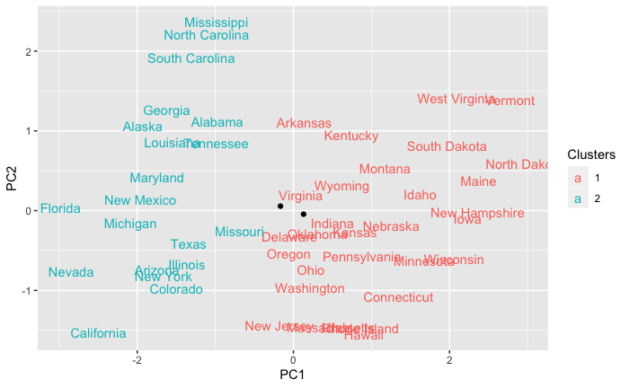

```r
pca_USArrests_df <- as.data.frame(pca_USArrests$x) %>%
  dplyr::select(PC1, PC2) %>%
  cbind(States = rownames(USArrests)) %>%
  cbind(Clusters = cluster)

c <- predict(pca_USArrests, centroid_points ) %>% as.data.frame()

ggplot(pca_USArrests_df, aes(x = PC1, y = PC2,)) + geom_text(aes(label = States, color = Clusters)) + geom_point(data =  centroid_coord, mapping =  aes(x = PC1, y = PC2))
```

We can generate new centroid values by taking the mean of all values of each observations that are part of the cluster

```r
new_centroid = USArrests_scaled %>%
  as.data.frame() %>%
  cbind(Clusters = cluster) %>%
  group_by(Clusters) %>%
  summarise_all(mean)
new_centroid
```

| Clusters | Murder | Assault | UrbanPop | Rape |
| --- | --- | --- | --- | --- |
| 1 | -0.6909475 | -0.7140829 | -0.2026187 | -0.6264652 |
| 2 | 0.8793877 | 0.9088328 | 0.2578783 | 0.7973194 |

```r
centroid_points = new_centroid[,-1] %>% as.matrix()
```

Rather than repeating the code over and over, we can write a function that will do it for us.

```r
k_means_ <- function(df, k, iters){
  #initialize random centroids
  centroids = sample.int(dim(df)[1], k)
  centroid_points = df[centroids,] %>% as.matrix()
  dataPoints <- as.matrix(df)

  #initialize WCSS
  within_cluster_ss <- c()

  for (i in 1:iters){
    dist_mat <- matrix(0, nrow = nrow(dataPoints), ncol = k)
    for (j in 1:k)
      {
        for (i in 1:nrow(dataPoints))
        {
        dist_mat[i,j] = sqrt(sum((dataPoints[i,1:ncol(dataPoints)] - centroid_points[j,1:ncol(centroid_points)])^2))
        }
      }

    cluster = factor(apply(dist_mat, 1, which.min))
    within_cluster_ss <- append(within_cluster_ss, colSums(dist_mat^2))

    new_centroid = df %>%
    as.data.frame() %>%
    cbind(Clusters = cluster) %>%
    group_by(Clusters) %>%
    summarise_all(mean)
    centroid_points = new_centroid[,-1] %>% as.matrix()
  }
  within_cluster_ss <- t(array(within_cluster_ss, dim = c(k, iters)))
  return(list(Cluster = cluster ,
              WCSS = within_cluster_ss))
}
```

```r
iters = 10
k = 2
USArrests_scaled <- scale(USArrests)
k_means <- k_means_(USArrests_scaled, k, iters)
k_means
```

```
$Cluster
 [1] 1 1 1 2 1 1 2 2 1 1 2 2 1 2 2 2 2 1 2 1 2 1 2 1 1 2 2 1 2 2 1 1 1 2 2 2 2 2 2 1 2 1 1 2 2 2 2 2 2 2
Levels: 1 2

$WCSS
          [,1]     [,2]
 [1,] 422.7855 428.8499
 [2,] 311.7856 267.4799
 [3,] 335.7064 258.0917
 [4,] 335.7064 258.0917
 [5,] 335.7064 258.0917
 [6,] 335.7064 258.0917
 [7,] 335.7064 258.0917
 [8,] 335.7064 258.0917
 [9,] 335.7064 258.0917
[10,] 335.7064 258.0917
```

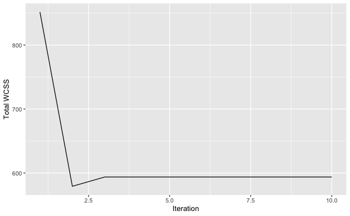

```r
df <- rowSums(k_means$WCSS) %>%
  as.data.frame() %>%
  cbind(iter = c(1:iters))

ggplot(df, aes(y = ., x = iter)) +
  geom_line() + labs(x = 'Iteration', y =  'Total WCSS')
```

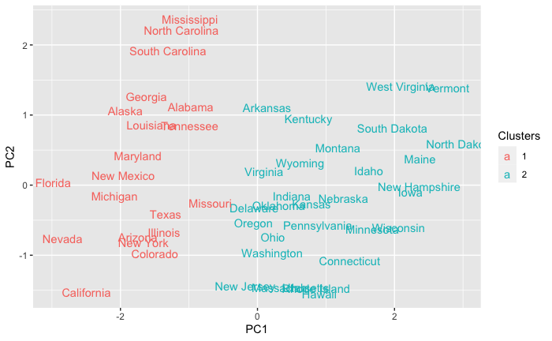

```r
pca_USArrests_df <- as.data.frame(pca_USArrests$x) %>%
  dplyr::select(PC1, PC2) %>%
  cbind(States = rownames(USArrests)) %>%
  cbind(Clusters = k_means$Cluster)

ggplot(pca_USArrests_df, aes(x = PC1, y = PC2,)) + geom_text(aes(label = States, color = Clusters))
```

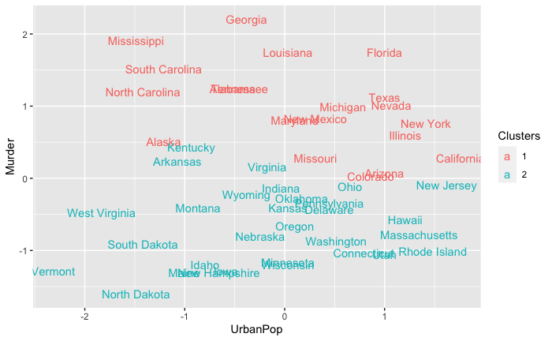

```r
USArrests_df <- USArrests_scaled %>%
  as.data.frame() %>%
  cbind(States = rownames(USArrests)) %>%
  cbind(Clusters = k_means$Cluster)

ggplot(USArrests_df, aes(x = UrbanPop, y = Murder,)) + geom_text(aes(label = States, color = Clusters))
```

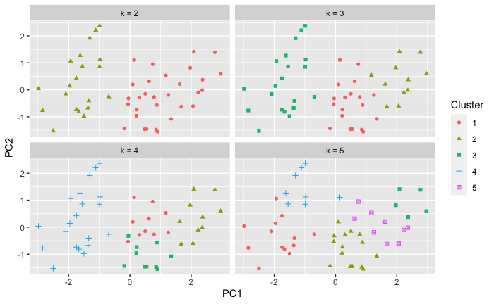

```r
k_means_test <- lapply(c(2:5), function(k) {k_means_(USArrests_scaled, k, iters)})
cluster_list <- lapply(k_means_test, function(x) x[[1]])
names(cluster_list) <- paste('k =',c(2:5))

cluster_list_df <- do.call(cbind, cluster_list)

pca_USArrests_df <- as.data.frame(pca_USArrests$x) %>%
  dplyr::select(PC1, PC2) %>%
  cbind(States = rownames(USArrests)) %>%
  cbind(cluster_list_df) %>%
  pivot_longer(cols = names(cluster_list))

ggplot(pca_USArrests_df, aes(x = PC1, y = PC2 )) + geom_point(aes(shape = factor(value), color = factor(value)) ) + facet_wrap(~name) + labs(color  = "Cluster", shape = "Cluster")
```

# Additional resources

- [K-means from Scratch R](https://www.section.io/engineering-education/k-means-from-scratch-r/)
- [Kmeans Clustering](https://uc-r.github.io/kmeans_clustering)
- [Data Mining Algorithms In R/Clustering/K-Means](https://en.wikibooks.org/wiki/Data_Mining_Algorithms_In_R/Clustering/K-Means)